# Preliminary_Statistics_Figures

2023-03-22

### Descriptives of variables

Here are some discriptive statistics and basic plots to see an overview of the data.

```r
# Physical activity level value (MET minutes)
#install.packages("table1")

data.frame(table1::table1(~MET_min_W + tot_MHC + tot_phc | Ex_3cat, data=thesis_NHRVS))
```

```
##                     X.   Insufficient       Moderate          Active
## 1                            (N=1427)        (N=724)        (N=1397)
## 2            MET_min_W
## 3            Mean (SD)     114 (98.2)     390 (66.8)       967 (389)
## 4    Median [Min, Max]   135 [0, 270] 405 [315, 495] 855 [540, 2000]
## 5              tot_MHC
## 6            Mean (SD)    1.21 (1.33)    1.02 (1.20)     1.04 (1.22)
## 7    Median [Min, Max] 1.00 [0, 6.00] 1.00 [0, 6.00]  1.00 [0, 6.00]
## 8              tot_phc
## 9            Mean (SD)    3.15 (2.11)    2.76 (1.80)     2.53 (1.86)
## 10   Median [Min, Max] 3.00 [0, 14.0] 3.00 [0, 9.00]  2.00 [0, 10.0]
##           Overall
## 1        (N=3548)
## 2
## 3       506 (462)
## 4   360 [0, 2000]
## 5
## 6     1.11 (1.26)
## 7  1.00 [0, 6.00]
## 8
## 9     2.82 (1.98)
## 10 3.00 [0, 14.0]
```

And some plots of the same values

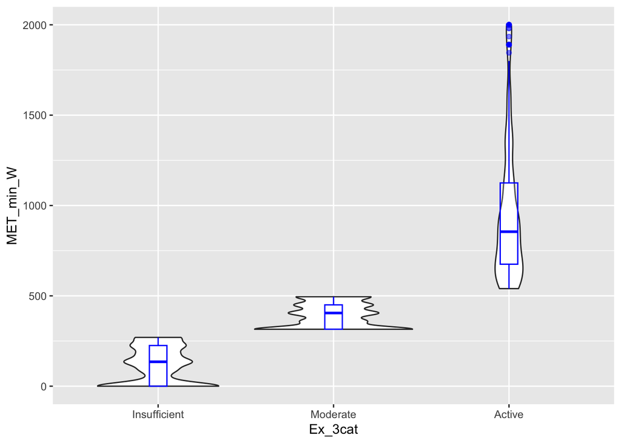

```r
#Plotting Met mins and Physical activity
ggplot(thesis_NHRVS, aes(x = Ex_3cat, y = MET_min_W)) +
  geom_violin()+
  geom_boxplot(width=0.1, color="blue", alpha=0.2)
```

```r
  ggtitle("Met minutes per physical activity level")
```

```
## $title
## [1] "Met minutes per physical activity level"
##
## attr(,"class")
## [1] "labels"
```

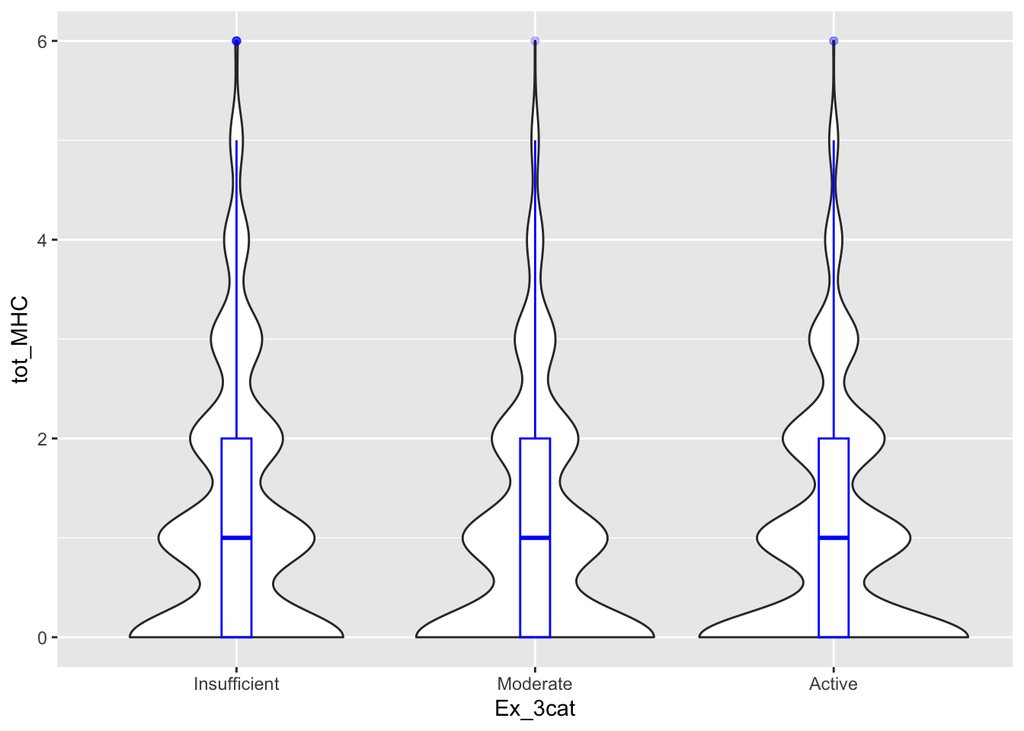

```r
# Total Mental health conditions
ggplot(thesis_NHRVS, aes(x = Ex_3cat, y = tot_MHC)) +
  geom_violin()+
  geom_boxplot(width=0.1, color="blue", alpha=0.2)
```

```r
  ggtitle("Total number of physical health conditions by PA level")
```

```
## $title
## [1] "Total number of physical health conditions by PA level"
##
## attr(,"class")
## [1] "labels"
```

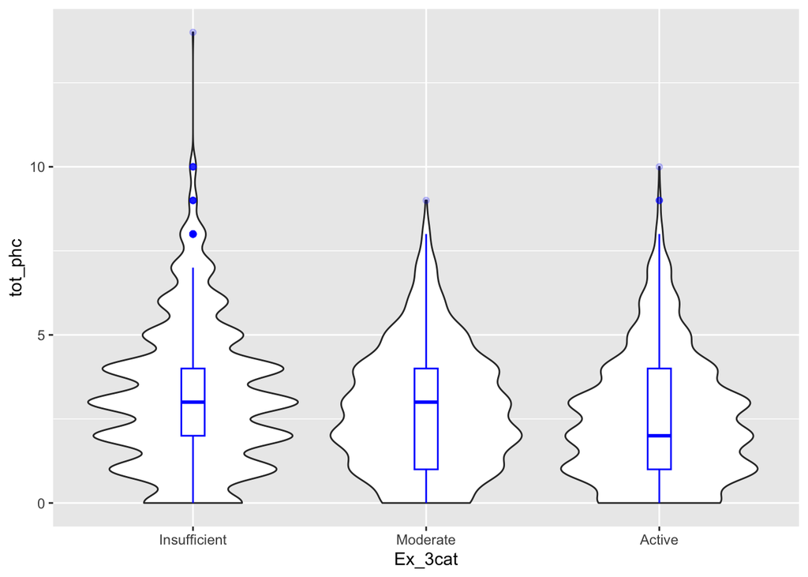

```r
# Total physical health conditions
ggplot(thesis_NHRVS, aes(x = Ex_3cat, y = tot_phc)) +
  geom_violin()+
  geom_boxplot(width=0.1, color="blue", alpha=0.2)
```

```r
  ggtitle("Total number of mental health conditions by PA level")
```

```
## $title
## [1] "Total number of mental health conditions by PA level"
##
## attr(,"class")
## [1] "labels"
```

### Barcharts of physical activity level by Health condition

Below is the code to create a barchart. This code was replicated for the remaining health conditions.

```r
library(scales)
```

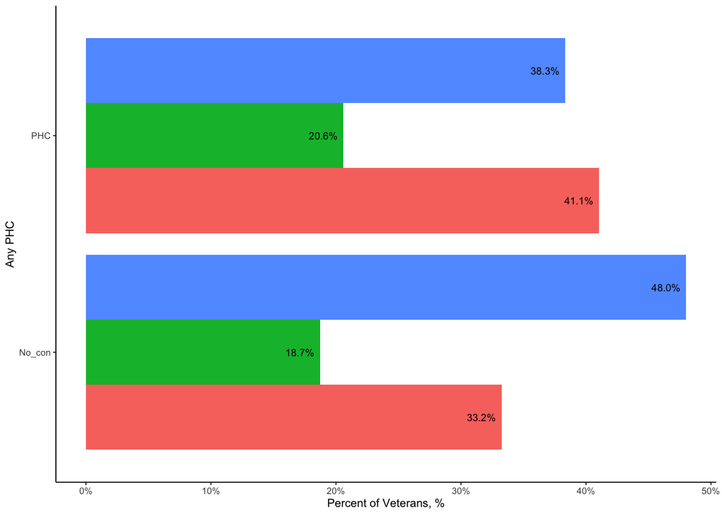

```r
#Any Physical Health Condition
Any_PHC_plot <-ggplot(thesis_NHRVS,aes(x=Any_PHC, fill = as.factor(Ex_3cat))) +
  geom_bar(aes( y=..count../tapply(..count.., ..x.. ,sum)[..x..]), position="dodge") +
  geom_text(aes( y=..count../tapply(..count.., ..x.. ,sum)[..x..], label=scales::percent(..count../tapply(..count.., ..x.. ,sum)[..x..]) ),
            stat="count", position=position_dodge(0.9), hjust = 1.2,size=2.5) +
  ylab('Percent of Veterans, %') +
  xlab('Any PHC')+
  labs(fill='Physical Activity') +
  scale_y_continuous(labels = scales::percent) +
  theme_classic(base_size=8)+
  theme(legend.position="none")+
  coord_flip()

Any_PHC_plot
```

### Physical Health Plots

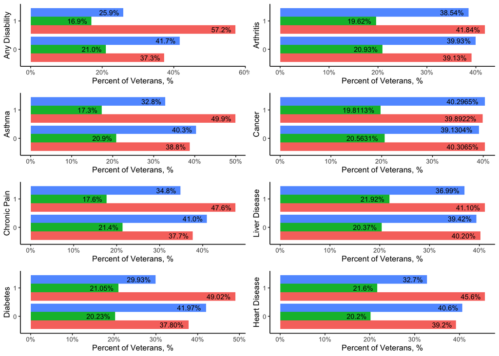

```r
library(ggpubr)
ggarrange(AD_Plot, ARTH_Plot, Aths_Plot, Cancer_plot,
                   Chron_pain_plot, Liv_dis_plot, Diabetes_plot, Hrt_dis_plot,
                   nrow = 4, ncol = 2)
```

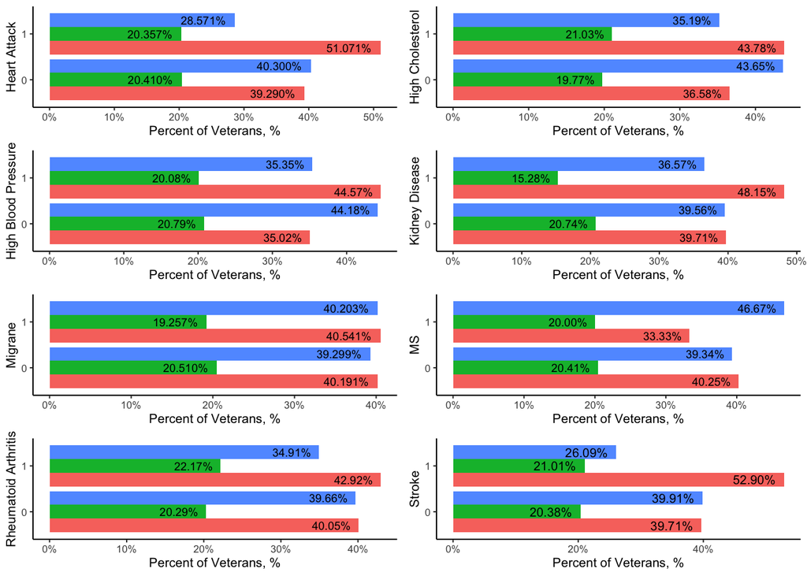

```r
ggarrange(Hrt_atk_plot, High_chol_plot, HBP_plot, KD_plot, Migrane_plot,
                   MS_plot, Rhum_arth_plot, Stroke_plot,
                   nrow = 4, ncol = 2)
```

### Mental Health. Plots

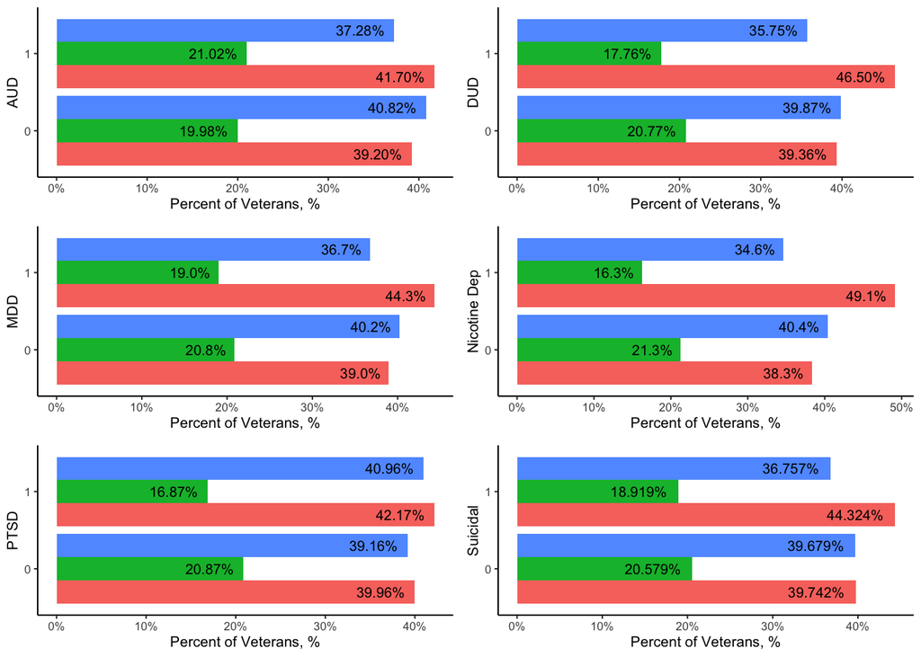

```r
ggarrange(LT_AUD_plot, LT_DUD_plot, LT_MDD_plot, LT_NicotineDep_plot, LT_PTSD_plot,
                   Suicidal_plot, nrow = 3, ncol = 2)
```

## Exploratory Data Analysis (EDA)

#### Associations With Exercsie

```r
library(tableone)
EX_Vars <- c("Age", "Male_Gender", "White_Race", "College",
                 "Married_Partnered", "Income_60k_plus", "YN_work", "PCS",
                 "MCS", "Weight_kg", "BMI", "Combat_Veteran",
                 "Yr5_Military", "TOTAL_TRAUMAS", "tot_phc",
                 "tot_MHC")

EX_catVars     <- c("Male_Gender", "White_Race", "College",
                 "Married_Partnered", "Income_60k_plus", "YN_work", "Combat_Veteran",
                 "Yr5_Military","Ex_3cat")
Exercise_EDA <- CreateTableOne(vars = EX_Vars, strata = "Ex_3cat", data = thesis_NHRVS,
               factorVars = EX_catVars)


full_sample<- CreateTableOne(vars = EX_Vars, data = thesis_NHRVS,
               factorVars = EX_catVars)
full_sample <- print(full_sample, formatOptions = list(big.mark = ","))

test_tab <- print(Exercise_EDA, formatOptions = list(big.mark = ","))
#Demo_tab <-
  test_tab[,1:4]
#View(Demo_tab)
Demo_tab <- cbind(full_sample, test_tab[,1:4])
```

#### Associations With Health Conditions

```r
Demo_tab<- as.data.frame(Demo_tab)
Demo_tab
```

```
##                                       Overall  Insufficient      Moderate
## n                                       3,548         1,427           724
## Age (mean (SD))                 66.25 (12.98) 67.19 (12.48) 67.15 (12.65)
## Male_Gender = Male (%)           3105 (87.5)   1231 (86.3)    643 (88.8)
## White_Race = White (%)           2903 (81.8)   1172 (82.1)    591 (81.6)
## College = Some_Colege (%)        3096 (87.3)   1197 (83.9)    624 (86.2)
## Married_Partnered = Single (%)   2514 (70.9)    978 (68.5)    514 (71.0)
## Income_60k_plus = Under_60k (%)  1458 (41.1)    659 (46.2)    284 (39.2)
## YN_work = Working (%)            2124 (59.9)    928 (65.0)    429 (59.3)
## PCS (mean (SD))                  46.65 (9.49) 43.48 (10.47)  47.79 (8.52)
## MCS (mean (SD))                  53.16 (7.68)  52.35 (8.37)  53.59 (6.93)
## Weight_kg (mean (SD))           90.16 (18.93) 92.96 (20.36) 90.14 (17.92)
## BMI (mean (SD))                  29.05 (5.49)  30.08 (6.01)  28.99 (5.29)
## Combat_Veteran = Combat (%)      1206 (34.0)    463 (32.5)    242 (33.4)
## Yr5_Military = 5+ (%)            1296 (36.5)    494 (34.6)    262 (36.2)
## TOTAL_TRAUMAS (mean (SD))         9.68 (8.28)   9.00 (7.86)  10.01 (8.50)
## tot_phc (mean (SD))               2.82 (1.98)   3.15 (2.11)   2.76 (1.80)
## tot_MHC (mean (SD))               1.11 (1.26)   1.21 (1.33)   1.02 (1.20)
##                                        Active      p           MHC
## n                                       1,397                2,048
## Age (mean (SD))                 64.84 (13.51) <0.001 64.38 (13.09)
## Male_Gender = Male (%)           1231 (88.1)   0.164  1755 (85.7)
## White_Race = White (%)           1140 (81.6)   0.926  1663 (81.2)
## College = Some_Colege (%)        1275 (91.3)  <0.001  1768 (86.3)
## Married_Partnered = Single (%)   1022 (73.2)   0.026  1400 (68.4)
## Income_60k_plus = Under_60k (%)   515 (36.9)  <0.001   905 (44.2)
## YN_work = Working (%)             767 (54.9)  <0.001  1228 (60.0)
## PCS (mean (SD))                  49.30 (7.81) <0.001  44.94 (9.95)
## MCS (mean (SD))                  53.77 (7.22) <0.001  51.09 (8.84)
## Weight_kg (mean (SD))           87.31 (17.46) <0.001 91.17 (19.37)
## BMI (mean (SD))                  28.04 (4.82) <0.001  29.45 (5.59)
## Combat_Veteran = Combat (%)       501 (35.9)   0.147   719 (35.2)
## Yr5_Military = 5+ (%)             540 (38.7)   0.082   741 (36.2)
## TOTAL_TRAUMAS (mean (SD))        10.22 (8.54) <0.001  11.27 (9.03)
## tot_phc (mean (SD))               2.53 (1.86) <0.001   3.06 (2.07)
## tot_MHC (mean (SD))               1.04 (1.22) <0.001   1.92 (1.10)
##                                        No_con      p        No_con
## n                                       1,500                  379
## Age (mean (SD))                 68.82 (12.37) <0.001 56.54 (14.19)
## Male_Gender = Male (%)           1350 (90.0)  <0.001   302 (79.7)
```

[output cut: 17 more lines]

```
## Male_Gender = Male (%)           2803 (88.5)  <0.001
## White_Race = White (%)           2599 (82.0)   0.430
## College = Some_Colege (%)        2761 (87.1)   0.537
## Married_Partnered = Single (%)   2247 (70.9)   0.900
## Income_60k_plus = Under_60k (%)  1320 (41.7)   0.057
## YN_work = Working (%)            2001 (63.1)  <0.001
## PCS (mean (SD))                  45.97 (9.58) <0.001
## MCS (mean (SD))                  53.14 (7.67)  0.552
## Weight_kg (mean (SD))           90.91 (19.01) <0.001
## BMI (mean (SD))                  29.26 (5.53) <0.001
## Combat_Veteran = Combat (%)      1100 (34.8)   0.010
## Yr5_Military = 5+ (%)            1151 (36.3)   0.494
## TOTAL_TRAUMAS (mean (SD))         9.90 (8.43) <0.001
## tot_phc (mean (SD))               3.16 (1.82) <0.001
## tot_MHC (mean (SD))               1.12 (1.26)  0.028
```

```r
write_csv(Demo_tab, "~/Desktop/Coding/data/Demo_tab_basic.csv")
```

These variables should be used for the regressions/ancovas - Age,Some_college_or_higher, Income_60K_plus, YN_work, PCS_final or MCS_final, combat veteran (maybe), weight (maybe?)

## Test of difference

This next section is extracting the F test score and chi square test (X) values for the analysis above. These values will be used in the final demogrpahics table

#### Physical activity levels

```r
library(gmodels)
#### Create test of difference values and put them into a table

#Age
Age_test_act <- aov(Age~ Ex_3cat, data = thesis_NHRVS)
test_act_vars = c('Age')
Activity_val = c(summary(Age_test_act)[[1]]$`F value`[[1]])
Activity_p = c(summary(Age_test_act)[[1]]$`Pr(>F)`[[1]])
Activity_val
```

```
## [1] 13.8453
```

```r
Activity_p
```

```
## [1] 1.0243e-06
```

F test and chi square will be extracted for the remaining variables: - Gender, White, some college, Married_partnered, Income 60k +, Working status, physical composite score, mental composite score, BMI, 5 years + in the military, total traumas, total physical health conditions, total mental health conditions.

```r
val_df <- data.frame(test_act_vars,Activity_val)
val_df <- cbind(val_df,Activity_p)
val_df
```

```
##           test_act_vars Activity_val   Activity_p
## 1                   Age   13.8452951 1.024300e-06
## 2                  Male    3.6197033 1.636784e-01
## 3                 White    0.1540486 9.258674e-01
## 4               College   35.5713654 1.887018e-08
## 5     Married_Partnered    7.3093010 2.587054e-02
## 6       Income_60k_plus   26.6195517 1.658203e-06
## 7               YN_work   30.2795478 2.659988e-07
## 8                   PCS  151.4903468 7.404521e-64
## 9                   MCS   13.5297159 1.400978e-06
## 10                  BMI   49.9954758 3.870961e-22
## 11       Combat Veteran    3.8387085 1.467017e-01
## 12 5+ Years in Military    5.0053933 8.186394e-02
## 13        TOTAL TRAUMAS    8.4014898 2.290337e-04
## 14            Total_PHC   36.1981881 2.739673e-16
## 15            Total MHC    9.0061062 1.254876e-04
```

#### Physical health Conditions

The same analysis will be conducted for these covariates by physical health condition as well.

#### Mental Health Conditions

```r
val_df <- cbind(val_df,MHC_val,MHC_p)
val_df
```

```
##           test_act_vars Activity_val   Activity_p      PHC_val        PHC_p
## 1                   Age   13.8452951 1.024300e-06 -14.28231132 2.054296e-38
## 2                  Male    3.6197033 1.636784e-01 302.00000000 1.061896e-06
## 3                 White    0.1540486 9.258674e-01   0.73914661 3.899344e-01
## 4               College   35.5713654 1.887018e-08   0.48746265 4.850613e-01
## 5     Married_Partnered    7.3093010 2.587054e-02   0.03425161 8.531726e-01
## 6       Income_60k_plus   26.6195517 1.658203e-06   3.84255594 4.996730e-02
## 7               YN_work   30.2795478 2.659988e-07 132.69344524 1.055082e-30
## 8                   PCS  151.4903468 7.404521e-64  17.85241969 6.868166e-58
## 9                   MCS   13.5297159 1.400978e-06   0.59277491 5.536157e-01
## 10                  BMI   49.9954758 3.870961e-22  -7.37198007 6.934982e-13
## 11       Combat Veteran    3.8387085 1.467017e-01   6.98722089 8.209372e-03
## 12 5+ Years in Military    5.0053933 8.186394e-02   0.54835963 4.589887e-01
## 13        TOTAL TRAUMAS    8.4014898 2.290337e-04  -5.27925030 1.893028e-07
## 14            Total_PHC   36.1981881 2.739673e-16 -97.92316260 0.000000e+00
```

[output cut: 17 more lines]

### Export to CSV

```r
write_csv(val_df, "~/Desktop/Coding/data/thesis_test_dif.csv" )
```